# Future 500- Advanced R Practice

### Submission by Connor Lenio. Email: cojamalo@gmail.com

Completion Date: May 4, 2017

## Assignment

You have been hired by the “Future 500” magazine*. The stakeholders have supplied you a list of 500 companies and would like you to create some draft visualizations for their upcoming online publication. They have requested the following charts:* A scatterplot classified by industry showing revenue, expenses, profit * A scatterplot that includes industry trends for the expenses~revenue relationship * BoxPlots showing growth by industry

Note that the dataset has numerous discrepancies that need to be addressed before analysis can be performed

## Data

Import the needed packages:

```r
library(data.table)
library(ggplot2)
library(dplyr)
```

Read the data into R using fread:

```r
all_data <- fread("Future-500.csv", na.strings = "", showProgress = FALSE) %>% tbl_df
```

### Data Cleaning

Identify those rows with incomplete information:

```r
all_data[!complete.cases(all_data),]
```

```
## # A tibble: 12 × 11
##       ID            Name           Industry Inception Employees State
##    <int>           <chr>              <chr>     <int>     <int> <chr>
## 1      3        Greenfax             Retail      2012        NA    SC
## 2      8       Rednimdox       Construction      2013        73    NY
## 3     11 Canecorporation             Health      2012         6  <NA>
## 4     14        Techline               <NA>      2006        65    CA
## 5     15         Cityace               <NA>      2010        25    CO
## 6     17         Ganzlax        IT Services      2011        75    NJ
## 7     22      Lathotline             Health        NA       103    VA
## 8     44       Ganzgreen       Construction      2010       224    TN
## 9     84      Drilldrill           Software      2010        30  <NA>
## 10   267      Circlechop           Software      2010        14  <NA>
## 11   332     Westminster Financial Services      2010        NA    MI
## 12   379       Stovepuck             Retail      2013        73  <NA>
## # ... with 5 more variables: City <chr>, Revenue <chr>, Expenses <chr>,
## #   Profit <int>, Growth <chr>
```

The relevant variables needed for the requested plots are `Industry`, `Revenue`, `Expenses`, `Profit`, and `Growth`. The missing information will definitely have to be addressed for these variables. Only missing data in these columns will qualify as grounds for excluding a row completely from the data, otherwise we can make simple changes to complete problem rows:

```r
all_data[all_data$City == "New York",]$State <- "NY"
all_data[all_data$City == "San Francisco",]$State <- "CA"
all_data[is.na(all_data$Employees),]$Employees <- median(all_data$Employees, na.rm = TRUE)
all_data[is.na(all_data$Inception),]$Inception <- median(all_data$Inception, na.rm = TRUE)
all_data[!complete.cases(all_data),]
```

```
## # A tibble: 5 × 11
##      ID      Name     Industry Inception Employees State       City
##   <int>     <chr>        <chr>     <int>     <dbl> <chr>      <chr>
## 1     8 Rednimdox Construction      2013        73    NY   Woodside
## 2    14  Techline         <NA>      2006        65    CA  San Ramon
## 3    15   Cityace         <NA>      2010        25    CO Louisville
## 4    17   Ganzlax  IT Services      2011        75    NJ     Iselin
## 5    44 Ganzgreen Construction      2010       224    TN   Franklin
## # ... with 4 more variables: Revenue <chr>, Expenses <chr>, Profit <int>,
## #   Growth <chr>
```

At this point, only rows with missing data from the variables of interest remain. The conservative approach is taken here and these rows are dropped to avoid adding in information into the plots that would have to be imputed or estimated. Then, all variables that should be numeric are properly converted from the character type. The `Industry` column is also factored in this step:

```r
comp_data <- all_data[complete.cases(all_data),]
comp_data$Industry <- factor(comp_data$Industry)
comp_data$Revenue <- as.numeric(gsub('[$,]', '', comp_data$Revenue))
comp_data$Expenses <- as.numeric(gsub('[,A-Za-z]', '', comp_data$Expenses))
comp_data$Growth <- as.numeric(gsub('[%]', '', comp_data$Growth))
```

## Data Visualization

Now, the data are ready to be plotted. The following are draft plots that address the requested information. After these plots are constructed, more information would be requested from the client to address any aesthetic needs for the plots, including titles and themes.

1. A scatterplot classified by industry showing revenue, expenses, profit

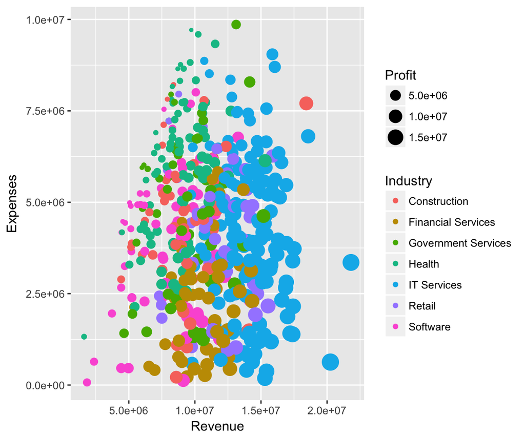

```r
ggplot(comp_data, aes(x = Revenue, y = Expenses, color = Industry, size= Profit)) + geom_point()
```

2. A scatterplot that includes industry trends for the expenses~revenue relationship

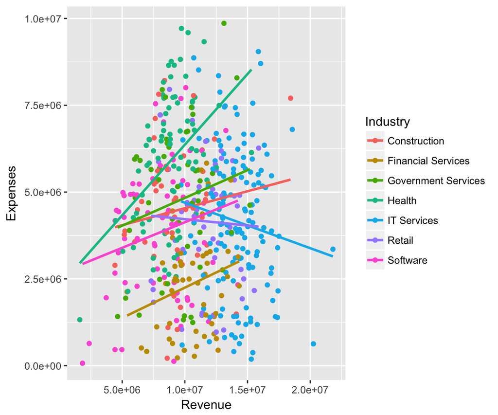

```r
ggplot(comp_data, aes(x = Revenue, y = Expenses, color = Industry)) + geom_point() +geom_smooth(method="lm",se=FALSE)
```

3) BoxPlots showing growth by industry

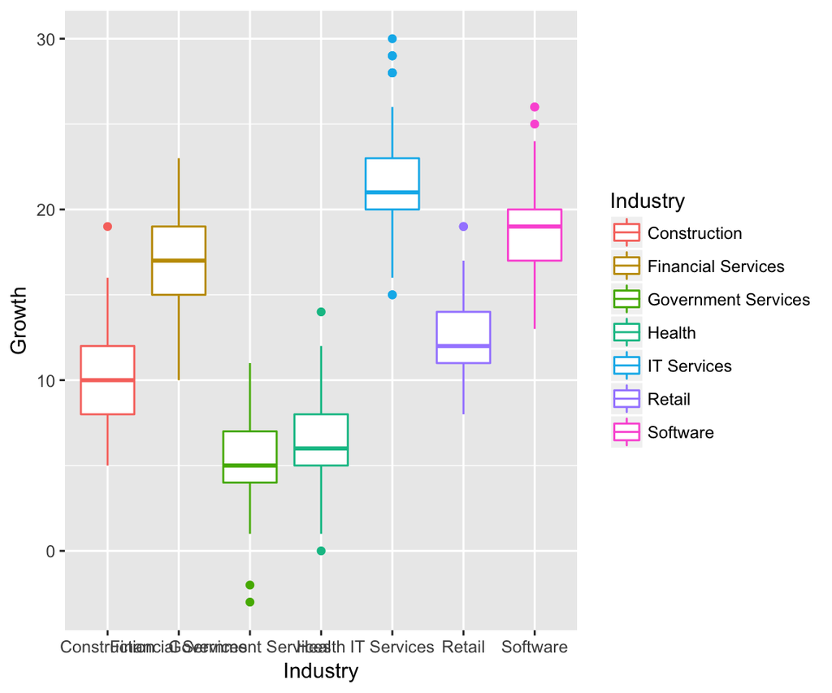

```r
ggplot(comp_data, aes(x = Industry, y = Growth, color = Industry)) + geom_boxplot()
```